# Map visualization using sf package

dondon

2021-01-16

```r
library(rgdal)
library(sp)
library(sf)
library(tidyverse)
library(data.table)
```

# 따릉이 대여소에서 한강까지의 최단거리 구하기

## 따릉이 대여소 정보 데이터 불러오기

서울시 공공 자전거 대여소 정보는 https://data.seoul.go.kr/dataList/OA-13252/F/1/datasetView.do 에서 다운로드가 가능하다.

```r
station <- fread('C:\\Users\\uos\\Desktop\\MASTER\\Spatial Data Analysis\\공공자전거 대여소 정보.csv')
colnames(station) <- c('대여소번호', '대여소명', '자치구', '상세주소', 'lat', 'long', '설치시기', 'LCD거치대수', 'QR거치대수', '운영방식')
station
```

```
##       대여소번호                                   대여소명 자치구                            상세주소      lat     long
##    1:       1695                        월계미륭아파트 정문 노원구                    노원구 월계동 14 37.62342 127.0669
##    2:       2301                        현대고등학교 건너편 강남구      서울특별시 강남구 압구정로 134 37.52407 127.0218
##    3:       2302 교보타워 버스정류장(신논현역 3번출구 후면) 강남구 서울특별시 강남구 봉은사로 지하 102 37.50558 127.0243
##    4:       2303                             논현역 7번출구 강남구   서울특별시 강남구 학동로 지하 102 37.51152 127.0215
##    5:       2304                       신영 ROYAL PALACE 앞 강남구        서울특별시 강남구 언주로 626 37.51253 127.0358
##   ---
## 2079:       2547                       포드서초서비스센터앞 서초구                         잠원동 55-1 37.51905 127.0123
## 2080:       1573                          현대성우아파트 옆 강북구                       미아동 670-33 37.61666 127.0221
## 2081:       1268                      몽촌토성역 1번출구 옆 송파구      서울특별시 송파구 방이동 88-21 37.51729 127.1142
## 2082:       1267                        올림픽공원 남2문 앞 송파구      서울특별시 송파구 올림픽로 424 37.51424 127.1231
## 2083:        583                         청계천 생태교실 앞 성동구     서울특별시 성동구 마장로39길 51 37.56797 127.0469
##         설치시기 LCD거치대수 QR거치대수 운영방식
##    1: 2020-06-17          NA         10       QR
##    2: 2017-06-13          10         NA      LCD
##    3: 2017-06-13          10         NA      LCD
##    4: 2017-06-13          15         NA      LCD
##    5: 2017-06-13          10         NA      LCD
##   ---
## 2079: 2020-05-28          NA         10       QR
## 2080: 2020-05-05          NA         10       QR
## 2081: 2020-06-25          NA         15       QR
## 2082: 2020-06-25          NA         15       QR
## 2083: 2020-06-30          NA          5       QR
```

```r
station_lcd <- station %>% filter(운영방식 == 'LCD') %>% select(대여소번호, 자치구, lat, long)
station_QR <- station %>% filter(운영방식 == 'QR') %>% select(대여소번호, 자치구, lat, long)
```

## 한강 데이터 불러오기

한강 데이터는 구글링하면 바로 구할 수 있다. 한강에서 뻗어나가는 하천 정보를 추가하고 싶으면 qgis에서 작업을 한 후에 shp 파일을 R로 불러오는 것이 가장 빠르다. 나는 한강 데이터에 북쪽의 법정하천을 추가해서 shp 파일을 만들었다.

```r
NA_W <- st_read("C:/Users/uos/Desktop/Master/bike sharing/river/river.shp")
```

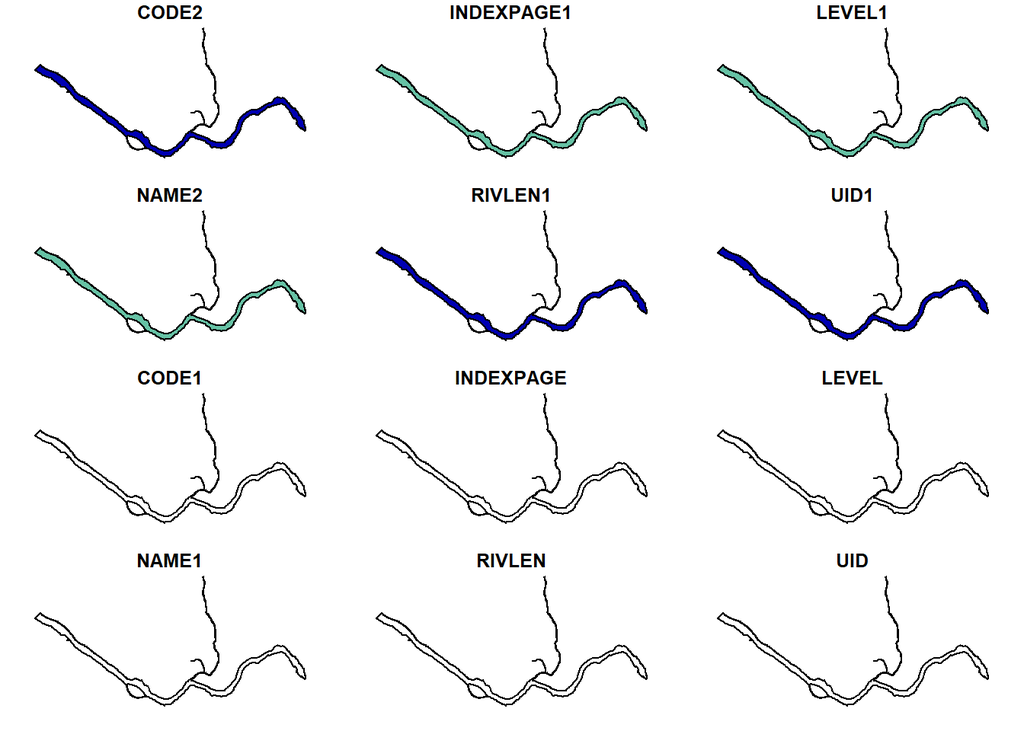

```r
plot(NA_W, max.plot = 12)
```

## 좌표계 변환

이전에 포스팅한 바와 같이 위도, 경도의 순서를 바꾸고 좌표계 변환을 해주는 코드이다.  
좌표계는 종류도 많고 복잡하기 때문에 접근하기가 쉽지 않은 것 같다. 데이터에 부여된 좌표계의 특징과 대략적인 의미만 파악해도 적용하는데는 무리가 없는 것 같다.  
간략하게 현재 사용하는 좌표계의 특징을 살펴보면 다음과 같다.  
* KATEC 계열: 한반도 전체를 하나의 좌표계로 나타낼 때 많이 사용하는 좌표계 * EPSG:5179 → UTM-K (GRS80) * 서비스: 네이버지도 * CRS 스펙: +proj=tmerc +lat_0=38 +lon_0=127.5 +k=0.9996 +x_0=1000000 +y_0=2000000 +ellps=GRS80 +units=m +no_defs

좌표계 설명 : https://www.osgeo.kr/17 좌표계 변환 코드 참고 : https://rpubs.com/KOOJA/coorinatesTransformationExample

```r
temp <- station_lcd

colnames(temp)[c(3,4)] = c("Y","X")
convertCoordSystem <- function(data = temp, from.crs = from.crs, to.crs = to.crs){
  xy = data.frame(long = data$X, lat = data$Y)
  xy = as.data.frame(apply(xy, 2, as.numeric))

  coordinates(xy) = ~long+lat

  from.crs = CRS(from.crs)
  from.coordinates = SpatialPoints(xy, proj4string=from.crs)

  to.crs = CRS(to.crs)
  changed = as.data.frame(SpatialPoints(spTransform(from.coordinates, to.crs)))
  names(changed) = c("long", "lat")

  return(changed)
}
```

```r
from.crs = "+proj=longlat +ellps=WGS84 +datum=WGS84 +no_defs"
to.crs = "+proj=tmerc +lat_0=38 +lon_0=127.5 +k=0.9996 +x_0=1000000 +y_0=2000000 +ellps=GRS80 +units=m +no_defs"
coord = convertCoordSystem(data = temp, from.crs = from.crs, to.crs = to.crs)
temp[,c(3,4)] = coord
colnames(temp)[c(3,4)] = c("X","Y")
coordinates(temp) = ~X+Y
temp = st_as_sf(temp , coord = c("X", "Y") , crs = 5179)
st_crs(temp) = st_crs(NA_W)
```

## 따릉이 대여소와 한강 사이의 최단거리 구하기

점과 점 사이의 거리를 구하는 것은 쉽지만 한강처럼 shp파일은 데이터의 형식이 polygon이므로 최단거리를 구하기가 쉽지 않다.  
그러나 R의 sf 패키지를 이용하면 쉽게 구할 수 있다. sf 패키지에 내장되어 있는 st_distance 함수를 이용하면 점과 polygon 사이의 최단거리를 구할 수 있다. by_elements = F 로 설정할 경우 거리에 대한 matrix를 반환한다.  
(sp 패키지에도 비슷한 함수가 내장되어있지만 sp 패키지와 sf 패키지를 혼용해서 사용할 수 없으므로 데이터의 형태를 sp 패키지에 맞는 데이터 형태로 변환해주어야 한다)

```r
d <- st_distance(NA_W, temp, by_element = T)
temp <- cbind(temp, d)
temp
```

```
## Simple feature collection with 1531 features and 3 fields
## geometry type:  POINT
## dimension:      XY
## bbox:           xmin: 938070.3 ymin: 1937734 xmax: 971761.8 ymax: 1965672
## projected CRS:  Korea 2000 / Unified CS
## First 10 features:
##    대여소번호 자치구             d                 geometry
## 1        2301 강남구  481.1772 [m] POINT (957744.4 1947304)
## 2        2302 강남구 2065.9254 [m] POINT (957953.8 1945252)
## 3        2303 강남구 1407.1250 [m] POINT (957709.7 1945912)
## 4        2304 강남구 2173.6376 [m] POINT (958979.2 1946017)
## 5        2305 강남구 1342.8372 [m] POINT (958866.3 1946918)
## 6        2306 강남구  728.8106 [m] POINT (958358.2 1947640)
## 7        2307 강남구  408.4248 [m] POINT (959228.7 1947801)
## 8        2308 강남구  394.0849 [m] POINT (958967.5 1947878)
## 9        2309 강남구 1021.5657 [m]   POINT (960180 1946719)
## 10       2310 강남구  890.1940 [m] POINT (959368.8 1947245)
```

## 데이터 병합

기존 데이터에 대여소 번호 기준으로 최단거리 데이터를 병합하면 최종 데이터가 완성된다.

```r
location <- data.frame(temp)[,c(1,3)]
location <- location %>% rename(distance = d)
location %>% head()
```

```
##   대여소번호      distance
## 1       2301  481.1772 [m]
## 2       2302 2065.9254 [m]
## 3       2303 1407.1250 [m]
## 4       2304 2173.6376 [m]
## 5       2305 1342.8372 [m]
## 6       2306  728.8106 [m]
```

```r
station_lcd <- left_join(station_lcd, location, by = '대여소번호')
station_lcd$distance <- as.numeric(station_lcd$distance)
station_lcd
```

```
##       대여소번호 자치구      lat     long  distance
##    1:       2301 강남구 37.52407 127.0218  481.1772
##    2:       2302 강남구 37.50558 127.0243 2065.9254
##    3:       2303 강남구 37.51152 127.0215 1407.1250
##    4:       2304 강남구 37.51253 127.0358 2173.6376
##    5:       2305 강남구 37.52064 127.0345 1342.8372
##   ---
## 1527:       1455 중랑구 37.59633 127.0859 1269.3175
## 1528:       1456 중랑구 37.59511 127.1003 2518.4152
## 1529:       1457 중랑구 37.58976 127.0932 1689.3536
## 1530:       1458 중랑구 37.59734 127.0931 1837.0942
## 1531:       1459 중랑구 37.59734 127.0931 1837.0942
```

[output not shown]